# 피라미드 없는 도제는 무엇으로 숙련을 복제하는가

저출생·고령화 × 의료 수련 × AI·수술로봇 안전공학

저자

Insight Lab

공개

2026년 11월 1일

**노트핵심 문장**

저출생 사회에서 의료의 병목은 의사라는 직업이 사라지는 데 있지 않다. **숙련자가 다음 숙련자를 곁에서 길러 내는 속도**가 환자 수요와 지식의 증가 속도를 따라가지 못하는 데 있다. AI와 로봇의 가장 가까운 역할은 의사를 없애는 일이 아니라, 수련의 일부를 복제 가능하게 만들고 전문의 한 명의 감독 범위를 넓히는 일이다.

# 1 0. 질문을 바꾸자

“옵티머스가 몇 년 안에 외과의를 대체할까”라는 질문은 눈길을 끈다. 2026년 1월 일론 머스크는 Optimus가 3년 안에 최고 외과의보다 나아질 것이라고 말했다. 그러나 이 말은 제품의 임상 성능이나 인허가 일정이 아니라 기업가의 전망이다. 같은 보도에서 의료윤리학자는 광범위한 인간 수술 적용에는 비교 임상 결과가 수년 필요하다고 반박했다. [The Independent 보도](https://www.independent.co.uk/tech/elon-musk-ai-optimus-surgeons-b2897000.html)

더 유용한 질문은 이것이다.

> **젊은 수련 인력은 줄고 환자는 늙어 가는데, 숙련은 어떤 장치로 다음 세대에 전달될 것인가?**

이 질문은 인구학, 의학교육, 안전공학을 한 번에 요구한다. 인구학은 수요와 공급의 비대칭을 보여 준다. 도제식 수련은 왜 그 비대칭에서 느려지는지 설명한다. 안전공학은 AI·로봇이 어디까지 사람의 일을 받아도 되는지 경계를 그린다.

# 2 1. 반등한 출생률과 계속되는 자연감소

한국의 2025년 합계출산율은 0.80으로 2024년의 0.75보다 올랐다. 출생아도 25만 4,500명으로 전년보다 1만 6,100명 늘었다. 반가운 변화다. 그러나 같은 해 사망자는 36만 3,400명으로, 자연증가(출생−사망)는 **−11만 명**이었다. 한 해의 반등은 장기 인구구조를 즉시 뒤집지 않는다. [국가데이터처, 2025년 출생·사망통계 잠정](https://mods.go.kr/board.es?act=view&bid=11773&list_no=444910&mid=a20101000000)

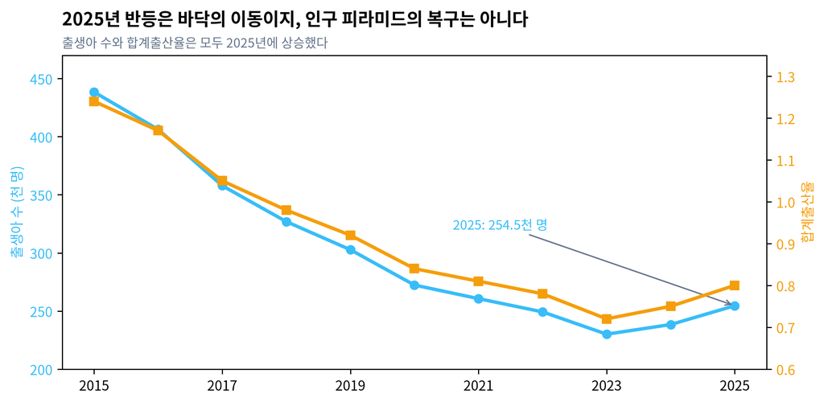

그림 1: 합계출산율과 출생아 수의 장기 하락 뒤 반등. 2025년의 개선은 사실이지만, 의료 수련에 들어올 연령대의 규모를 단기에 바꾸지는 못한다. 출처: 국가데이터처 2025년 출생·사망통계(잠정).

이 사실에서 곧바로 “의사가 없어질 것”이라고 결론 내릴 수는 없다. 의대 정원, 이민, 지역 배치, 간호·보조 인력, 진료 방식도 변하기 때문이다. 다만 수련을 받는 사람 한 명의 시간이 희소해지고, 고령 환자의 복합적 진료 수요가 늘어나는 방향은 분명하다. 의료 체계는 사람 수뿐 아니라 **숙련을 만드는 처리량**을 늘려야 한다.

# 3 2. 도제의 약점은 1:1이 아니라 ’보지 못한 경우’다

도제식 수련은 결함만 있는 제도가 아니다. 숙련된 전문의의 판단은 교과서에 모두 적히지 않는다. 수술 중 예상과 다른 해부학, 갑작스러운 출혈, 환자의 미세한 생체 신호는 숙련자가 상황을 해석하며 보여 주는 방식으로 전달된다. 그래서 도제를 영상 강의로 단순 대체할 수 없다.

하지만 전통 도제에는 확장성의 문제가 있다. 한 명의 스승이 동시에 관찰하고 피드백할 수 있는 수습자의 수는 제한되어 있다. 특히 수습자가 **드문 합병증을 실제 환자에서 처음 만나는 순간**은, 훈련과 안전이 충돌하는 순간이다. 젊은 인력이 감소할수록 각 사람에게 당직·진료·수련이 한꺼번에 몰리고, 관찰과 피드백에 쓸 시간이 먼저 잘린다.

여기서 AI 시뮬레이터와 수술 데이터는 도제를 없애는 것이 아니라 세 층으로 분해한다.

1. **반복 가능한 층**: 기구 조작, 영상 판독의 기초, 표준 절차는 시뮬레이터에서 반복한다.
2. **감독 가능한 층**: 원격 지도와 녹화된 수술 데이터로 전문의 한 명이 더 많은 수련자를 검토한다.
3. **책임이 남는 층**: 적응증 판단, 예외 상황, 환자와의 설명·동의, 중단 결정은 인간 의료진이 맡는다.

이 구조의 목표는 “수련 기간을 기계적으로 줄이는 것”이 아니다. 실제 환자에게 처음 시도해야 하는 행동의 수를 줄이고, 전문의의 피드백을 기록 가능한 형태로 늘리는 것이다.

# 4 3. 노동력 제공형 도제에서 역량 중심 수련으로

과거의 장시간 수련을 그대로 복원하는 것은 답이 아니다. 한국의 전공의 수련은 이미 당직을 포함해 원칙적으로 주당 80시간 상한을 두고 있다. 보건복지부도 2024년 수련혁신 방안에서 평균 수련시간을 80시간에서 72시간으로 낮추고, 단계적으로 60시간 수준을 검토하는 시범사업을 제시했다. 동시에 지도전문의 지원, 임상교육훈련센터 확대, 다기관 협력 수련을 내걸었다. [보건복지부 의료개혁 1차 실행방안](https://mohw.go.kr/menu.es?mid=a50103000000)

이 변화는 단순히 시간이 줄었다는 뜻이 아니다. 병원이 전공의의 장시간 노동으로 빈 자리를 메우는 구조에서는, 시간이 줄수록 교육 기회도 함께 줄 수 있다. 그래서 전공의를 ‘진료 인력’과 ’피교육자’ 중 하나로 고르는 식의 이분법도 충분하지 않다. 진료 참여는 교육의 핵심이지만, 그 참여가 **관찰·피드백·위임 기준** 없이 반복 업무에 흡수되면 수련이 아니라 인력 운용이 된다.

개혁의 단위는 병원 운영과 교육 평가를 같이 바꾸는 일이다.

| 바꿀 대상 | 기존의 노동력 제공형 도제 | 역량 중심 수련 |
| --- | --- | --- |
| 투입 기준 | 연차·당직표 중심 | 시뮬레이션과 직접관찰을 통과한 술기 단위 |
| 지도 방식 | 같은 현장에 있었는가 | 영상·로그·다수 지도자의 기록 피드백 |
| 전문의 역할 | 공백을 메우며 사후 감독 | 위임 기준을 정하고 고위험 판단을 직접 담당 |
| 병원 운영 | 전공의 수에 진료 용량이 연동 | 전문의 중심 진료와 교육 시간을 별도 확보 |
| 평가 기준 | 사례 수·근속 기간 | 맡겨도 되는 수준(entrustment)과 환자안전 결과 |

시뮬레이션은 실제 수술을 대신하는 면허증이 아니다. 다만 드물지만 치명적인 상황을 같은 조건으로 반복하고, 실패를 환자에게 전가하지 않은 채 끝까지 경험하게 한다는 장점이 있다. WHO는 시뮬레이션의 장점으로 희귀·긴급 상황 반복, 동일 시나리오의 비교, 오류를 실제 환자 위험 없이 끝까지 관찰하는 점을 든다. [WHO Patient Safety Curriculum Guide](https://iris.who.int/bitstream/handle/10665/44641/9789241501958_eng.pdf?sequence=)

역량 중심 평가는 추상적 구호도 아니다. ACGME의 평가 지침은 직접관찰, 술기 시뮬레이터·가상현실, 수술 사례 로그, 영상으로 포착된 술기, 다면 피드백을 함께 쓰는 방법을 제시한다. 중요한 것은 AI가 점수를 내는 것이 아니라, **어떤 증거가 있어야 지도전문의가 다음 술기를 맡길 수 있는지**를 미리 정하는 것이다. [ACGME Clinical Competency Committees Guidebook](https://www.acgme.org/globalassets/acgmeclinicalcompetencycommitteeguidebook.pdf)

# 5 4. 수술로봇의 현재 위치: 자율의 약속보다 감독의 설계

FDA가 2026년 공개한 로봇수술기기 초안 가이드는 로봇보조수술기기(RASD)를 **자격 있는 의료진이 수술기구를 정밀하게 위치·제어하도록 돕는 원격조작·소프트웨어 제어 시스템**으로 정의한다. 임상 자료, 비임상 시험, 표시사항을 요구하는 전임상 심사 대상이다. [FDA RASD 초안 가이드](https://www.fda.gov/regulatory-information/search-fda-guidance-documents/robotically-assisted-surgical-devices-premarket-submissions)

FDA도 원격조작과 특정 작업의 자율성이 환자 진료를 바꿀 가능성을 인정한다. 동시에 자율·원격 기능의 이익과 위험을 별도로 논의하고 있다. [FDA Robotic Medical Devices](https://www.fda.gov/medical-devices/products-and-medical-procedures/robotic-medical-devices)

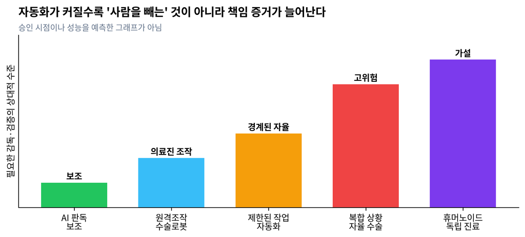

그림 2: 의료 자동화의 책임 사다리. 이 그림은 시장 규모나 승인 시점을 예측하지 않는 안전 설계 모형이다. 오른쪽으로 갈수록 필요한 임상 근거·감사·책임 배분이 커진다. 출처: FDA의 RASD 및 로봇 의료기기 규제 설명을 바탕으로 작성.

따라서 현실적인 순서는 휴머노이드 의사가 병원을 채우는 장면이 아니다. 먼저 영상·기록·경보를 정리하는 AI, 이어 특정 동작을 정밀하게 돕는 수술로봇, 그 다음에는 명확한 조건과 즉시 중단 가능한 제한 작업의 자동화가 온다. 각 단계에서 중요한 질문은 “로봇이 할 수 있는가”보다 다음 네 가지다.

- 어떤 환자·적응증에서만 허용하는가?
- 이상 징후를 누가, 얼마나 빨리 감지하는가?
- 사람이 언제 즉시 넘겨받는가?
- 사고가 나면 제조사·병원·감독 의료진의 책임과 기록은 어떻게 남는가?

# 6 5. 인구절벽이 요구하는 것은 ’의사 없는 병원’이 아니다

저출생은 자동화를 정당화하는 면허가 아니다. 사람이 부족하다고 검증되지 않은 자율 수술을 취약 환자에게 먼저 적용하면, 의료 공백을 줄이는 대신 위험을 불평등하게 배분할 수 있다. 특히 지역·필수의료일수록 “대안이 없으니 먼저 써 보자”는 유혹이 강하다.

반대로 아무것도 바꾸지 않는 것도 중립이 아니다. 수련 인력의 과로, 지방의 전문의 공백, 대기시간 증가는 이미 환자에게 비용을 전가한다. 그래서 필요한 정책 단위는 로봇 한 대의 도입이 아니라 다음의 **감독 가능한 확장**이다.

| 병목 | 단기 수단 | 안전장치 |
| --- | --- | --- |
| 반복 훈련 시간 | 고충실도 시뮬레이터·술기 로그 | 실제 환자 수술과 분리된 평가 |
| 전문의 피드백 부족 | 원격 멘토링·수술 영상 검토 | 지도 책임과 피드백 기록 |
| 야간·지역 공백 | 원격협진·의사결정 보조 | 최종 처방·전원 기준은 의료진 |
| 표준 동작의 피로 | 경계된 로봇 보조 | 즉시 수동 전환·사건 로그 |

도제는 사라지지 않는다. 대신 “한 명의 스승이 옆에서 지켜봐야만 전달되는 지식”의 비중을 줄이고, 기록·시뮬레이션·원격감독으로 복제할 수 있는 부분을 넓혀야 한다. 도제의 핵심은 위계가 아니라 **피드백이 책임과 함께 전달되는 것**이기 때문이다.

# 7 6. 반대해석: 기술이 아니라 보상·근무환경이 병목일 수 있다

**경고반대해석과 한계**

- 저출생이 필수의료 기피의 유일한 원인은 아니다. 보상, 법적 위험, 근무시간, 지역 인프라, 조직문화가 더 직접적인 원인일 수 있다. 로봇을 넣어도 이 조건을 고치지 않으면 사람은 돌아오지 않는다.
- 이 글의 인구 데이터는 국가 단위다. 특정 과의 전공의 수, 지역별 대기시간, 수술 결과를 직접 측정하지 않았다. 그러므로 특정 진료과의 인력 부족 규모를 이 숫자로 계산할 수 없다.
- 자동화 사다리는 예측이 아니다. FDA의 규제 설명을 바탕으로 책임과 검증이 증가하는 방향을 그린 설계 모형이다. 2030년이나 2035년의 자율수술 보급률을 말하지 않는다.
- AI가 특정 영상 판독이나 제한된 절차에서 강해져도, 환자 전체의 진단·설명·의사결정을 대체한다는 뜻은 아니다. 성능은 데이터 분포, 장비, 환자 선택, 감독 방식에 따라 달라진다.

# 8 결론: 도제를 자동화하지 말고, 숙련의 피드백을 확장하자

도제식 의료 수련의 위기는 “젊은 사람이 적으니 로봇의사가 필요하다”는 직선 논리가 아니다. 더 정확한 연쇄는 이렇다.

> 인구구조 변화는 수련자 한 명에게 요구되는 시간을 무겁게 만든다. 도제는 그 시간을 숙련자의 현장 관찰로 바꾼다. AI·로봇은 관찰·반복·기록의 일부를 확장할 수 있다. 그러나 예외 상황의 책임을 지우지는 못한다.

따라서 좋은 의료 AI 정책의 기준은 자율성의 높이가 아니라, **얼마나 안전하게 수련의 피드백 루프를 넓히는가**다. 완전 자율 휴머노이드 의사는 먼 가설로 남겨 두어도 된다. 지금 필요한 것은 환자를 실험 대상으로 삼지 않고도 더 많은 사람이 더 빨리, 더 잘 배우게 하는 인프라다.

# 9 참고 문헌

1. [국가데이터처, *Preliminary Results of Birth and Death Statistics in 2025* (2026-02-25)](https://mods.go.kr/board.es?act=view&bid=11773&list_no=444910&mid=a20101000000)
2. [FDA, *Robotically-Assisted Surgical Devices — Premarket Submissions*, Draft Guidance (2026-09)](https://www.fda.gov/regulatory-information/search-fda-guidance-documents/robotically-assisted-surgical-devices-premarket-submissions)
3. [FDA, *Robotic Medical Devices*](https://www.fda.gov/medical-devices/products-and-medical-procedures/robotic-medical-devices)
4. [Harry Cockburn, *Elon Musk says AI surgeons will be better than humans in just three years*, The Independent (2026-01-08)](https://www.independent.co.uk/tech/elon-musk-ai-optimus-surgeons-b2897000.html)
5. [보건복지부, *의료개혁 1차 실행방안* (2024-08-30)](https://mohw.go.kr/menu.es?mid=a50103000000)
6. [ACGME, *Clinical Competency Committees Guidebook*](https://www.acgme.org/globalassets/acgmeclinicalcompetencycommitteeguidebook.pdf)
7. [WHO, *Patient Safety Curriculum Guide*](https://iris.who.int/bitstream/handle/10665/44641/9789241501958_eng.pdf?sequence=)